# R Data Visualization

## XY-scatter plots

As mentioned in the Excel section, XY-scatter plots differ from line plots. In XY-scatter plots, the data on the x-axis are separated according to their value instead as being used as labels.

XY-scatter plots are often used to demonstrate a correlation.

Let’s first start with a small example for an XY-scatter plot:

```r
scatter_data <- tibble(
  protein_conc_ug_ml = c(1, 2, 5, 10, 15, 20, 25, 30),
  fluorescence       = c(120, 245, 580, 1150, 1720, 2310, 2950, 3480)
)
formatted_table(head(scatter_data))
```

| protein_conc_ug_ml dbl | fluorescence dbl |
| --- | --- |
| 1 | 120 |
| 2 | 245 |
| 5 | 580 |
| 10 | 1150 |
| 15 | 1720 |
| 20 | 2310 |

And an XY scatter plot:

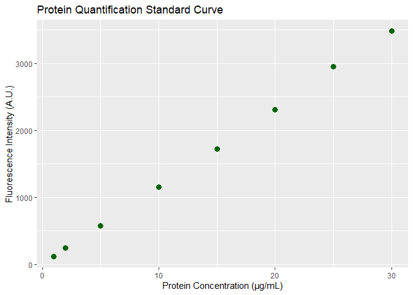

```r
p <- scatter_data %>%
  ggplot(aes(x = protein_conc_ug_ml, y = fluorescence)) +
  geom_point(size = 3, color = "darkgreen") +
  labs(
    title = "Protein Quantification Standard Curve",
    x = "Protein Concentration (µg/mL)",
    y = "Fluorescence Intensity (A.U.)"
  )
p
```

And we can add a linear trendline “layer” as follows:

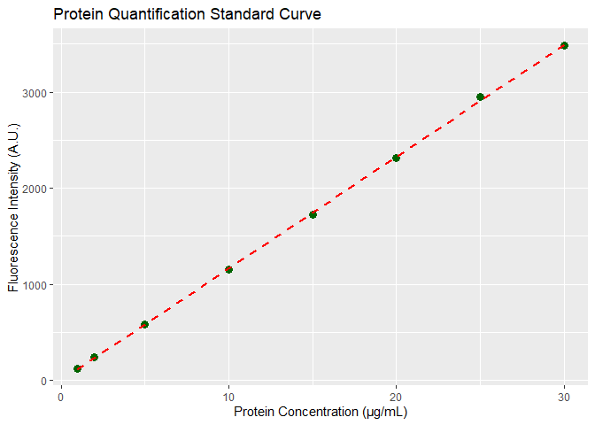

```r
p <- scatter_data %>%
  ggplot(aes(x = protein_conc_ug_ml, y = fluorescence)) +
  geom_point(size = 3, color = "darkgreen") +
  geom_smooth(method = "lm", se = FALSE, color = "red", linetype = "dashed") +
  labs(
    title = "Protein Quantification Standard Curve",
    x = "Protein Concentration (µg/mL)",
    y = "Fluorescence Intensity (A.U.)"
  )
p
```

And now a larger example:  
As for the Excel section, we will use the ChickWeight data set from R to create a scatter plot using ggplot2. First we take only the data from Diet 1:

```r
chickwts_diet1 <- ChickWeight %>%
  filter(Diet == 1)
formatted_table(head(chickwts_diet1))
```

| weight dbl | Time dbl | Chick ord | Diet fct |
| --- | --- | --- | --- |
| 42 | 0 | 1 | 1 |
| 51 | 2 | 1 | 1 |
| 59 | 4 | 1 | 1 |
| 64 | 6 | 1 | 1 |
| 76 | 8 | 1 | 1 |
| 93 | 10 | 1 | 1 |

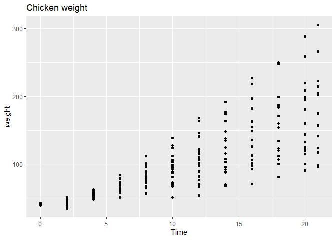

```r
p <- chickwts_diet1 %>%
  ggplot(aes(x = Time, y = weight)) +
  geom_point() +
  labs(title="Chicken weight")
p
```

And then we can add a linear regression model:

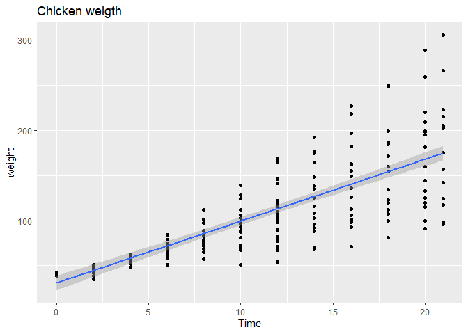

```r
p <- chickwts_diet1 %>%
  ggplot(aes(x = Time, y = weight)) +
  geom_point() +
  labs(title="Chicken weigth") +
  geom_smooth(method="lm")
p
```

Note that the standard error is included as we did not use the `se = FALSE` argument.

## Bubble chart

Like Excel, ggplot2 also supports bubble charts:

If you have data that is most suitable to present in a XY-grid but you have an extra dimension, bubble charts might be a good chart type.

Bubble charts are a great way to display data that includes three variables. In the context of a laboratory, here is an example of a data set that could be presented in a bubble chart:

Suppose you have collected data on the protein concentration for different analysis methods. In addition, you have also measured the analysis time for each method and the analysis volume (number of assays per day).

To display this data in a bubble chart, you could use the following format:

X-axis: Analysis time (minutes)  
Y-axis: Protein concentration (mg/mL)  
Bubble size: Represents the number of assays per day in the laboratory.

By using a bubble chart to display this data, you can quickly see patterns and trends among the different types of protein quantification methods, the required analysis time as well as their number of analysis per day.

First we will load the same data:

```r
library(readxl)
file_path <- "./files_12_data_visualization/file04_bubble_chart.xlsx"
bubble_data <- read_excel(file_path)
formatted_table(head(bubble_data))
```

| Method chr | Analysis time (min) dbl | Protein concentration (mg/ml) dbl | Number of Analyses per day dbl |
| --- | --- | --- | --- |
| Lowry | 120 | 40 | 60 |
| Bradford | 120 | 65 | 60 |
| BCA | 90 | 75 | 30 |
| UV/VIS | 10 | 50 | 400 |
| Kjedahl | 15 | 85 | 800 |

And now we can create a bubble chart:

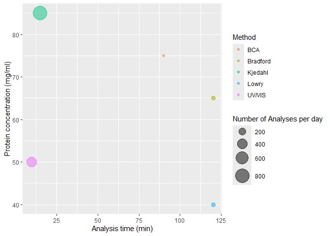

```r
p <- bubble_data %>%
  ggplot(aes(x = `Analysis time (min)`, y = `Protein concentration (mg/ml)`)) +
  geom_point(aes(color = Method, size = `Number of Analyses per day`), alpha = 0.5) +
  scale_size_area(max_size = 10)
p
```

The Chart includes the following:

X-axis: Analysis time (minutes).  
Y-axis: Protein concentration (mg/mL).  
Bubble size: Represents the number of assays per day in the laboratory.

## Other plot types and libraries

ggplot2 offers many more plot types. Way beyond the capabilities of Excel. For an example gallery of supported plot types in ggplot2 see [this link](http://r-statistics.co/Top50-Ggplot2-Visualizations-MasterList-R-Code.html).  
In addition, other packages exist for even more plotting capabilities in R.

Go back to the main page  
Go back to the R overview page  
⬆️ Back to Top

> This web page is distributed under the terms of the Creative Commons Attribution License which permits unrestricted use, distribution, and reproduction in any medium, provided the original author and source are credited. Creative Commons License: CC BY-SA 4.0.